Inspired [by a tweet](https://twitter.com/albertlyu/status/485529440160448512) by Albert Lyu, I recently discovered that the [Gameday site](http://gd2.mlb.com/components/) that host PITCHf/x and other play-by-play data also hosts play-by-play for minor league games. The new version of pitchRx (1.5) adds support for acquiring play-by-play data from any major or minor league game.

## Using gameday identifiers

In [my last post](http://baseballwithr.wordpress.com/2014/06/30/pitchrx-meet-openwar-4/), I discussed how to use gameday identifiers to acquire data for specific games. If you want minor league play-by-play data, you’ll have to use this approach (at least for now). To demonstrate, consider the default behavior of `scrape` when using a `start` and `end` date:

```r
library(pitchRx)
dat <- scrape(start = "2012-01-01", end = "2013-01-01")
```

This returns *any* game that a major league team played in during 2012. This includes games between major league and minor league teams. Note that the previous use of `scrape` is equivalent to the following approach using gameday identifiers (that is, `gids`).

```r
data(gids, package = "pitchRx")
gids12 <- gids[grepl("2012", gids)]
dat <- scrape(game.ids = gids12)
gids12[[1]]
```

```
## [1] "gid_2012_02_29_fanbbc_phimlb_1"
```

The first game in `gids12` is between Florida State University Seminoles (which has a team code of ‘fan’) and the Philadelphia Phillies (which has a team code of ‘phi’). The ‘bbc’ bit after ‘fan’ is a league code that let’s us know that, in this case, the away team ‘fan’ is a college team. Similarly, the ‘mlb’ bit after ‘phi’ tells us the home team is an MLB team. To gain some insight on both the type and quantity of games by league type, consider the following:

```r
league.away <- substr(gids12, 19, 21)
league.home <- substr(gids12, 26, 28)
table(paste(league.away, league.home, sep = "-"))
```

```
##
## aaa-mlb afa-mlb bbc-mlb min-mlb mlb-aaa mlb-aax mlb-afa mlb-jml mlb-mlb
##       1       1      10       3       4       3       1       4    2976
```

That is, nearly 3000 games between major league teams are available and about 25 other games (where either the home or away team is a minor league team) are available for data aquisition. Here is a table of translations for all currently available league codes ([thanks Albert and Harry](https://twitter.com/albertlyu/status/485643587011354624)):

| Code | Full name |
| --- | --- |
| aaa | Triple A |
| aax | Double A |
| afa | High A |
| afx | Low A |
| asx | Short Season A-ball |
| bbc | College |
| hsb | High School |
| int | World Baseball Classic |
| jml | Japanese |
| min | Generic Minors |
| mlb | Major League Baseball |
| nae | Junior National Team |
| nat | National Team |
| rok | Rookie Ball |
| win | Winter League |

## Acquiring data from non-MLB games

As we’ve seen, the `gids` data object that comes packaged with pitchRx contains games with at least one MLB team, but what about *non*-MLB games? The new `nonMLBgids` object provides similar identifiers for non-MLB games which can be used to acquire data just like `gids`. For example, say I want any triple A game played on June 1st. First, let’s extract the appropriate set of identifiers from all the available identifiers:

```r
data(nonMLBgids, package = "pitchRx")
aaa <- nonMLBgids[grepl("2011_06_01_[a-z]{3}aaa_[a-z]{3}aaa", nonMLBgids)]
```

Now we just pass these gameday identifiers to `scrape`‘s `game.ids` argument. Note that we can also use the `suffix` argument in the usual way to acquire data from more file types than just the ’inning/inning_all.xml’ default.

```r
dat <- scrape(game.ids = aaa, suffix = c("inning/inning_all.xml",
                                         "inning/inning_hit.xml",
                                         "players.xml",
                                         "miniscoreboard.xml"))
```

```
## If file names don't print right away, please be patient.
```

[output not shown]

[output cut: 12 more lines]

[output not shown]

Since we specified ‘inning/inning_hit.xml’ in `suffix`, the ‘hip’ (hits-in-play) table is one of the many returned by `scrape`. Let’s use this data to plot all the hits in play on June 1st. This turns out to be very easy with some help from openWAR.

```r
library(openWAR)
```

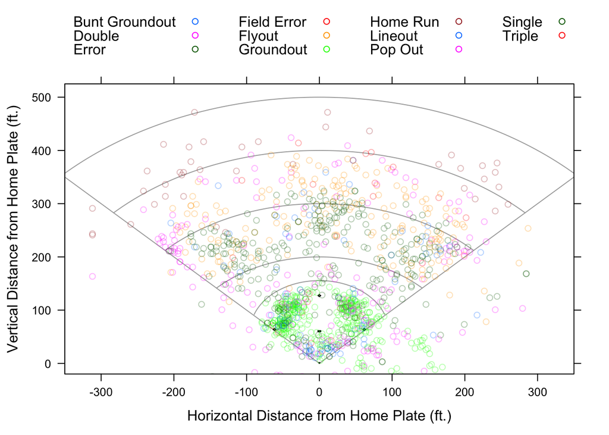

```r
# 'recenter' hit locations
hip.day <- openWAR:::recenter(dat$hip)
class(hip.day) <- c("GameDayPlays", "data.frame")
names(hip.day) <- sub("des", "event", names(hip.day))
plot(hip.day)
```

## That’s a lot of games!

It turns out that `nonMLBgids` will increase the number of games we are able to acquire using `scrape` by about 5 fold. Remember that `gids` contained about 3000 identifiers from 2012, `nonMLBgids` contains about 15000.

```r
nonMLB12 <- nonMLBgids[grep("2012", nonMLBgids)]
length(nonMLB12)
```

```
## [1] 15052
```

And those non-MLB games from 2012 broken down by league type:

```r
league.away <- substr(nonMLB12, 19, 21)
league.home <- substr(nonMLB12, 26, 28)
table(paste(league.away, league.home, sep = "-"))
```

```
##
## aaa-aaa aaa-aax aaa-afa aax-aax afa-aaa afa-afa afx-afx asx-asx bbc-aax
##    3242       1       1    2231       1    2236    2189     875       2
## bbc-afx bbc-asx bbc-bbc int-int min-min mlb-min nat-nae rok-rok win-win
##       2       2       6      24       2       1       1    2975    1261
```

## Building a non-MLB database

Since non-MLB games don’t have PITCHf/x, the columns required for the ‘pitch’ table is a much smaller subset (compared to MLB games). This is just one reason why you probably want to keep you’re MLB tables separated from non-MLB tables. I think it’s easiest to just create another database. Also, since `nonMLBgids` provides access to over 100,000 games, one should think carefully about which games they actually want/need. For instance, I could start a “nonMLB” database and fill it with every Triple A game.

```r
db <- src_sqlite("nonMLB.sqlite3", create = TRUE)
# logical vector with TRUE if the home OR away league is Triple A
aaa <- grepl("[a-z]{3}aaa_[a-z]{6}", nonMLBgids) | grepl("[a-z]{6}_[a-z]{3}aaa", nonMLBgids)
aaaGids <- nonMLBgids[aaa]
# DISCLAIMER: This scrapes a lot of games! Be patient!
scrape(game.ids = nonMLBgids, connect = db$con)
```